# session_08

## Neural Networks and Deep Learning

In a previous exercise, you built your own simple neural network (perceptron) and implemented the gradient descent optimizer. Hopefully that helped you build some intuition of how a neural network learns. The perceptron is a very simple model, and thus quite limited in its application. More complicated tasks require more sophisticated optimizers, cost functions as well as network architectures.

This week, we will use the python deep learning library [Keras](https://keras.io/) and learn how to build a basic neural network with it. These exercises have been adapted from the [tensorflow tutorial](https://www.tensorflow.org/tutorials/keras) as well as the book *Deep Learning with Python* by François Chalet.

In the first part of this notebook, you'll find a fully worked through example of the classic machine learning problem of handwritten digit classification. This should prepare you for the first exercise, where you will tackle a very similar problem — the classification of articles of clothing.

In the second exercise, we move to another common type of problem: a regression problem. You will use the Boston Housing Price dataset and try to predict the median price of homes in a given Boston suburb.

These introductory problems are intentionally kept brief and rather simple. The main goal of this week is for you to get a taste of how to tackle common machine learning problems and develop a good workflow that can easily be adapted for other, more elaborate problems.

After this exercise, you will be able to

- solve simple image classification & regression tasks with keras
- employ cross-validation to estimate the validation error

*Keywords*: neural networks: deep learning, keras, activation function, optimzer, loss function — image classification: handwritten digits, clothing — regression: house prices — cross validation

```python
import numpy as np
import seaborn as sns
import matplotlib as mpl
import matplotlib.pyplot as plt
import tensorflow.keras as keras
import pandas as pd
from sklearn import model_selection

sns.set_context("notebook")
```

```
INFO:tensorflow:Enabling eager execution
INFO:tensorflow:Enabling v2 tensorshape
INFO:tensorflow:Enabling resource variables
INFO:tensorflow:Enabling tensor equality
INFO:tensorflow:Enabling control flow v2
```

#### Prelude: TensorFlow Playground

Before starting with the exercise, I invite you to have a look at https://playground.tensorflow.org/ and have some fun with it for a while!

### A first look at a neural network

Let's look at a fully-worked through example of a neural network built in *Keras*. The problem we will solve is a machine learning classic: classification of handwritten digits with the MNIST dataset.

```python
(train_images, train_labels), (test_images, test_labels) = keras.datasets.mnist.load_data()
```

```
Downloading data from https://storage.googleapis.com/tensorflow/tf-keras-datasets/mnist.npz
```

The MNIST datasets is already split into a training and test set, as you should know is good practice. As usual, the first step is to explore the structure of the data.

```python
train_images.shape
```

```
(60000, 28, 28)
```

```python
len(train_labels)
```

```
60000
```

```python
train_labels
```

```
array([5, 0, 4, ..., 5, 6, 8], dtype=uint8)
```

```python
test_images.shape
```

```
(10000, 28, 28)
```

The training data consists of 60'000 samples of 28x28 grayscale images and their corresponding labels. The test data contains of 10'000 samples. Let's have a look at a single sample from the training data.

```python
digit = train_images[2]
print(digit.shape)
plt.imshow(digit, cmap=plt.cm.binary)
plt.xticks([])
plt.yticks([])
plt.xlabel(train_labels[2])
```

```
(28, 28)
```

[figure not shown]

For humans, it's very easy to correctly identify the above picture as a '4'. Actually, it will just require a few lines of code to train a neural network to be quite good at this task, as well. The first step of this (after loading the data) is to build the network.

```python
network = keras.models.Sequential()
network.add(keras.layers.Dense(512, activation="relu", input_shape=(28 * 28,)))
network.add(keras.layers.Dense(10, activation="softmax"))
```

The basic building block is the *layer*, and the network above consists of fully connected (dense) layers. The first layer has 512 neurons assigned to it. You can think of the first layer as a function that takes a 2D tensor (28 x 28) as an input and returns another tensor. To be more precise, it performs the *relu* tensor operation $relu(Z) = max(Z, 0)$, where $Z = W \cdot X + b$. Here, $X$ is the input tensor and $W$ and $b$ are the weights and are properties of the layer. The second layer is a 10-way [softmax](https://en.wikipedia.org/wiki/Softmax_function) layer, meaning it will return an array of 10 probability scores. Take a moment and think about what shapes $X, W$ and $b$ are in this specific example.

The network's layers are now defined, but we still need to assign three very important properties: a loss function, an optimizer and metrics to monitor during training and testing.

```python
network.compile(optimizer="rmsprop", loss="categorical_crossentropy", metrics=["accuracy"])
```

Before proceeding, we should pre-process the data a bit by reshaping it into the shape the network expects. In the first layer from above, we assigned it an input shape of (28 * 28), meaning we need to flatten the training and test data. Also, we will scale the data so that all values are in the [0, 1] interval.

```python
train_images = train_images.reshape((60000, 28 * 28))  # reshape the training data
train_images = train_images.astype("float32") / 255  # normalize the training data (255 = max rgb(?) num) -> each pixel [0,1]

test_images = test_images.reshape((10000, 28 * 28))  # rehsape the test data
test_images = test_images.astype("float32") / 255  # normalize the test data
```

Another requirement is that the labels need to be encoded categorically. *Categorical encoding* (also called one-hot encoding) embeds each label as a vector with all coefficients set to zero except with a one at the label index. What should the shape of the encoded training labels be?

```python
train_labels = keras.utils.to_categorical(train_labels)
test_labels = keras.utils.to_categorical(test_labels)
train_labels.shape
```

```
(60000, 10)
```

This is everything we need to do and we can start to train the network. With Keras, this is done by calling the network's *fit* method.

```python
history = network.fit(train_images, train_labels, epochs=5, batch_size=128)
```

```python
loss = history.history["loss"]
```

Ofcourse you also want to actually test whether the neural network works on the test data as well.

```python
test_loss, test_acc = network.evaluate(test_images, test_labels)
print("Test accuracy", test_acc)
```

```
Test accuracy 0.9776999950408936
```

It is quite common for the test accuracy to be lower than the training accuracy. This is one example of *overfitting*, demonstrating that neural networks in general tend to perform worse on test data.

The network is trained and evaluated, it can now be used to make predictions about some images. The prediction will be an array of 10 confidence values of the model that correspond to the digits from 0 to 9.

```python
predictions = network.predict(test_images)
predictions[0]
```

```
array([3.1449229e-08, 1.7368412e-08, 3.8520502e-06, 7.8512334e-05,
       6.1909339e-10, 3.0167703e-07, 1.3190324e-12, 9.9987745e-01,
       1.3918310e-06, 3.8341004e-05], dtype=float32)
```

It's easy to check which label has the highest confidence value and compare it to the actual label.

```python
predicted_label = np.argmax(predictions[0])
# reverse the categorical encoding
actual_label = np.int(np.where(test_labels[0] == 1)[0])
print("Predicted label:", predicted_label)
print("Actual label:", actual_label)
```

```
Predicted label: 7
Actual label: 7
Deprecated in NumPy 1.20; for more details and guidance: https://numpy.org/devdocs/release/1.20.0-notes.html#deprecations
  actual_label = np.int(np.where(test_labels[0] == 1)[0])
```

### Train your first neural network with *Keras*: basic classification

The first exercise is another version of the handwritten digit classification from above, but this time, you will classify articles of clothing. You will use the fashion MNIST dataset that contains 70'000 grayscale images in 10 clothing categories. Start by loading the dataset with Keras. As usual, we split it into training and test sets.

```python
fashion_mnist = keras.datasets.fashion_mnist
(train_images, train_labels), (test_images, test_labels) = fashion_mnist.load_data()
```

The labels are stored in arrays of integers from 0 to 9 that correspond to the class of clothing represented in the image. Each integer is mapped onto a class of clothing uniquely. Since the class names are not included in the dataset, the array is defined below.

```python
class_names = [
    "T-shirt/top",
    "Trouser",
    "Pullover",
    "Dress",
    "Coat",
    "Sandal",
    "Shirt",
    "Sneaker",
    "Bag",
    "Ankle boot",
]
```

### Exercise 1:

- Explore the data in the usual fasion.
- Preprocess the data by scaling the data in a meaningful way.
- Plot a collection of images from the training set and display the class name below each image.
- Encode the labels categorically.
- Build the model.
- Compile the model: you can use the same parameters as in the previous model.
- Train and evaluate the model.
- Make predictions about some images; translate the integer output into a class name.
- Play around with the network a bit by changing the number of neurons, epochs or choose a different optimizer (take a look at the keras documentation).

```python
# to-do: explore the data
print(train_images.shape)
print(train_labels)
print(test_images.shape)

sample_img = train_images[2]
print(sample_img.shape)
plt.imshow(sample_img, cmap=plt.cm.binary)
plt.xticks([])
plt.yticks([])
plt.xlabel(class_names[train_labels[2]])
```

```
(60000, 28, 28)
[9 0 0 ... 3 0 5]
(10000, 28, 28)
(28, 28)
```

[figure not shown]

```python
# to-do: preprocess the data
train_images = train_images / 255
test_images = test_images / 255
```

```python
# to-do: plot a collection of images
# hint: take a look at plt.subplot()
plt.figure(figsize=(10,10))
for i in range(25):
    plt.subplot(5, 5, i + 1)
    plt.imshow(train_images[i], cmap=plt.cm.binary)
    plt.xlabel(class_names[train_labels[i]])
    plt.xticks([])
    plt.yticks([])
```

[figure not shown]

```python
# to-do: encode the labels
train_labels_enc = keras.utils.to_categorical(train_labels)
test_labels_enc = keras.utils.to_categorical(test_labels)
train_labels_enc.shape
```

```
(60000, 10)
```

The network consists of three layers. The first layer is simply flattening the input array, similar to what we've done separetely in the example above. Add two more densely (fully) connected layers with appropriate activation functions and number of neurons.

```python
# to-do: build the model
# the first layer should be of the form layers.Flatten(input_shape=(x, y))
# alternatively, you can omit that layer and reshape the input yourself
model = keras.models.Sequential()
model.add(keras.layers.Flatten(input_shape=(28, 28)))
model.add(keras.layers.Dense(128, activation="relu"))
model.add(keras.layers.Dense(10, activation="softmax"))
```

```python
# to-do: compile the model
model.compile(optimizer="rmsprop", loss="categorical_crossentropy", metrics=["accuracy"])
```

```python
# to-do: train the model
model.fit(x=train_images, y=train_labels_enc, epochs=8)
```

```
<tensorflow.python.keras.callbacks.History at 0x2480a134a30>
```

```python
# to-do: evaluate accuracy
test_loss, test_acc = model.evaluate(x=test_images, y=test_labels_enc)
print("Test accuracy: ", test_acc)
print("Test loss: ", test_loss)
```

```
Test accuracy:  0.8849999904632568
Test loss:  0.4187709391117096
```

```python
# to-do: make predictions about some images
pred = model.predict(test_images)
pred_lab = np.argmax(pred[0])

print('Predicted label:', class_names[pred_lab])
print('Actual label:', class_names[test_labels[0]])
```

```
Predicted label: Ankle boot
Actual label: Ankle boot
```

The helper functions below make it possible to easily look at a bunch of images and the associated predictions.

```python
cmap = mpl.cm.get_cmap("Paired")
col_true = cmap(1)
col_false = cmap(5)


def plot_image(i, predictions_array, true_label, img):
    """ Plot an image and sets the x-label
    to the predicted class.

    Args:
    i (int) :: index to select an item from
               prediction_array, true_label and img
    predictions_array (array) :: predicted labels
    true_label (array) :: true labels
    img (array) :: image to be plotted
    """
    assert isinstance(i, int)
    predictions_array, true_label, img = predictions_array[i], true_label[i], img[i]
    plt.grid(False)
    plt.xticks([])
    plt.yticks([])

    plt.imshow(img, cmap=plt.cm.binary)

    predicted_label = np.argmax(predictions_array)
    if predicted_label == true_label:
        color = col_true
    else:
        color = col_false

    plt.xlabel(
        "{} {:2.0f}% ({})".format(
            class_names[predicted_label],
            100 * np.max(predictions_array),
            class_names[true_label],
        ),
        color=color,
    )


def plot_value_array(i, predictions_array, true_label):
    """ Create a bar plot of the predictions.

    Args:
    i (int) :: index to select an item from
               predictions_array and true_label
    predictions_array (array) :: predicted labels
    true_labels (array) :: true labels
    """
    assert isinstance(i, int)
    predictions_array, true_label = predictions_array[i], true_label[i]
    plt.grid(False)
    plt.xticks([])
    plt.yticks([])
    thisplot = plt.bar(range(10), predictions_array, color="#777777")
    plt.ylim([0, 1])
    predicted_label = np.argmax(predictions_array)

    thisplot[predicted_label].set_color(col_false)
    thisplot[true_label].set_color(col_true)
```

```python
# Plot the first X test images, their predicted label, and the true label
# Color correct predictions in blue, incorrect predictions in red
num_rows = 5
num_cols = 3
num_images = num_rows * num_cols
plt.figure(figsize=(2 * 2 * num_cols, 2 * num_rows))
for i in range(num_images):
    # to-do: plot images by calling the plot_image
    plt.subplot(num_rows, num_cols * 2, 2 * i+1)
    plot_image(i, pred, test_labels, test_images)
    # and plot_value_array functions
    plt.subplot(num_rows, num_cols * 2, 2 * i+2)
    plot_value_array(i, pred, test_labels)
plt.show()
```

[figure not shown]

### Regression with neural networks: predicting house prices

The two previous examples were *classification* problems, meaning the goal was to predict a single discrete label as a function of an input. Another common type of problem in machine learning is when the algorithm should predict a continuous value — these are *regression* problems. You've already seen them in previous weeks.

The second exercise focuses on regression with neural networks. You will use the Boston Housing Price dataset and attempt to predict the median price of homes in a given Boston suburb in the mid-1970s. As an input, you will have data about, for example, local property tax or crime rate.

Again, the dataset can be loaded with keras. You have a number of training/test samples, each with some numerical features, such as per capita crime rate, average number of rooms per house, and so on. The target arrays hold the median values of owner-occupied homes, measured in thousands of USD (houses were cheap in the 70s). We are also creating a dataframe from the training data that can be used to create pair plots.

```python
(train_data, train_targets),(test_data, test_targets) = keras.datasets.boston_housing.load_data()

training_data = np.append(train_data, train_targets.reshape(train_data.shape[0], -1), axis=1)
df = pd.DataFrame(training_data)
```

### Exercise 2:

- Explore the data; use seaborn to create a pairplot and look for possible correlations by eye.
- Preprocess the data by performing the standardization feature scaling.
- This time, we define a python function that builds and compiles the network. Fill in the blanks.

```python
# to-do: explore the data
print(train_data.shape)
print(train_targets.shape)
print(train_targets[::50])

#sns.pairplot(df)
```

```
(404, 13)
(404,)
[15.2 18.7 46.  13.5 23.9 12.7 21.9 22.7 25.2]
```

Recall that the feature scaling is transforming the features like so: $\tilde{x} = (x - \mu) / \sigma$. When standardizing the data, be careful that you calculate the mean/standard deviation along the right axis. Also standardize the test data *using the quantities calculated from the training data*. It is important to *never* use quantities computed on the test data.

```python
# to-do: standardize the data
mu = train_data.mean(axis=0)
sd = train_data.std(axis=0)

train_data -= mu
train_data /= sd

test_data -= mu
test_data /= sd
```

As you've seen above, there are only few samples available. You'll use a quite small network with *two* hidden layers, each with 64 neurons, and one output layer with only a single neuron. This is common practice when you are trying to predict a single value, as is the case here. We don't want to add an activation function at the last layer because that will constrain the output to a certain range (think of the sigmoid function). Your last layer should have a single neuron corresponding to the prediction. All the layers are fully (densely) connected. For the activation function, you can use "relu" again.

When you compile the model, you can use the same optimizer as in the first example. For the loss, you should use the mean squared error ("mse"), while the metric is the mean absolute error (["mae"]). This is the absolute value of the difference between predictions and targets.

Here's a summary of the network:

- 1st layer: dense layer with 64 neurons using the "relu" activation function with the appropriate input_shape specified.
- 2nd layer: dense layer with 64 neurons using the "relu" activation function.
- 3rd layer: dense layer with 1 neuron, no activation function.
- Optimizer: "rmsprop", loss: "mse", metrics: ["mae"]

**Click me if you are stuck:**

Here's how the build_model function should look like: ``` def build_model(): model = keras.models.Sequential() model.add(keras.layers.Dense(64, activation='relu', input_shape=(train_data.shape[1],))) model.add(keras.layers.Dense(64, activation='relu')) model.add(keras.layers.Dense(1)) model.compile(optimizer='rmsprop', loss='mse', metrics=['mae']) return model ```

```python
# to-do: complete the function that builds & compiles the network
def build_model():
    model = keras.models.Sequential()
    # to-do: add layers and compile the model
    model.add(keras.layers.Dense(64, activation="relu", input_shape=(train_data.shape[1],)))
    model.add(keras.layers.Dense(64, activation="relu"))
    model.add(keras.layers.Dense(1))

    model.compile(optimizer="rmsprop", loss="mse", metrics=["mae"])
    return model
```

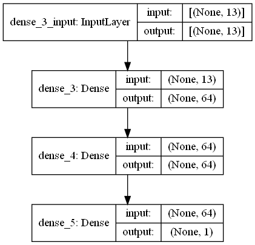

```python
model = build_model()

import os
os.environ["PATH"] += os.pathsep + "C:/Program Files/Graphviz/bin/"

keras.utils.plot_model(model, to_file="network.png", show_shapes=True)
```

The network architecture is defined, let's proceed by training and evaluating the model.

Since the dataset is quite small, we can use the k-fold cross-validation method to split the available training data into partial training and validation sets. This can be done by calling *model_selection.KFold(n_splits=k)* from *sklearn*.

### Exercise 3:

- Train and evaluate the model on four k-folds. Store the mean absolute error in a list after each validation and then in the end compute the average.
- Modify the training/validation loop to keep a record of how well the model is doing at each epoch and save the per-epoch validation score log.
- Compute the average of the per-epoch MAE and plot it against the number of epochs.
- Try and figure out after how many epochs you should stop the training.
- Train your final model with the ideal number of epochs, make some predictions, and plot the true values vs the predicted values.

**Click me if you need don't remember how to create the k-folds:**

``` kf = model_selection.KFold(n_splits=4) kf.get_n_splits(train_data) # create the splits ```

When fitting the model, also pass the two additional arguments *batch_size=1* and *verbose=0* to the fit method. *batch_size* is the number of samples per gradient update, and *verbose=0* stops the output from appearing in your console.

```python
# to-do: create the k-fold splits
kf = model_selection.KFold(n_splits=4)
kf.get_n_splits(train_data)

# to-do: train and evaluate the model on the splits
test_scores = []
num_epochs = 50

i = 1
for train_idx, val_idx in kf.split(train_data):
    print("processing fold #", i)
    # to-do: implement the training/evaluation loop
    model = build_model()
    history = model.fit(x=train_data[train_idx], y=train_targets[train_idx],
        validation_data=(train_data[val_idx], train_targets[val_idx]),
        epochs=num_epochs, verbose=0)

    # and store the mae in test_scores
    test_scores.append(history.history["val_mae"])
    # remember that you have to build a new model at
    # each iteration step
    i += 1

print("Test scores:", test_scores)
print("Mean test score: {:.4f}".format(np.mean(test_scores)))
```

[output not shown]

As you can see, the different runs can show quite different validation scores. That's why cross-validation yields a much better estimate for the validation error.

In the next step, you can try at least 200 (up to 500) epochs, depending on how much time you have (and how powerful your computer is). At each k-fold iteration, store the mae history in all_mae_histories.

```python
# to-do: modified training/validation loop
kf = model_selection.KFold(n_splits=4)
kf.get_n_splits(train_data)

all_mae_histories = []
num_epochs = 200

i = 1
for train_idx, val_idx in kf.split(train_data):
    print("processing fold #", i)
    # to-do: implement the training/evaluation loop
    model = build_model()
    history = model.fit(x=train_data[train_idx], y=train_targets[train_idx],
        validation_data=(train_data[val_idx], train_targets[val_idx]),
        epochs=num_epochs, verbose=0)
    # hint:
    # assign your model to a variable, e.g.,
    # history = model.fit(X, Y, validation_data=(X_val, Y_val), **kwargs)
    # then you can get the mae history with
    # history.history['val_mae']
    # note that written like this, the fit method also evaluates the model
    # automatically
    all_mae_histories.append(history.history["val_mae"])
    i += 1
```

[output not shown]

```python
# to-do: compute the average of the per-epoch MAE and plot it against the number of epochs
average_mae_history = [np.mean([x[i] for x in all_mae_histories]) for i in range(num_epochs)]

plt.plot(range(1, len(average_mae_history) + 1), average_mae_history)
plt.xlabel("epoch")
plt.ylabel("validation mae")
```

[figure not shown]

It's a little difficult to see a trend because of issues with scaling and the high variance. We can try the smoothing with the following function (exponential moving average of the previous points) and omitting the first 10 epochs.

```python
def smooth_curve(points, factor=0.9):
    smoothed_points = []
    for point in points:
        if smoothed_points:
            previous = smoothed_points[-1]
            smoothed_points.append(previous * factor + point * (1 - factor))
        else:
            smoothed_points.append(point)
    return smoothed_points
```

```python
# to-do: plot the smoothed mae history
smooth_mae_history = smooth_curve(average_mae_history[10:])

plt.plot(range(1, len(smooth_mae_history) + 1), smooth_mae_history)
plt.xlabel("epoch")
plt.ylabel("validation mae")
```

[figure not shown]

Let's train the final model and make some predictions. This time, the training is done on the full data and you can set *batch_size* to 16.

```python
# to-do: train the final model and make some predictions
model = build_model()
model.fit(x=train_data,y=train_targets, epochs=80, batch_size=16, verbose=0)

test_mse_score, test_mae_score = model.evaluate(test_data, test_targets)

print('Test mse score: {:.2f}'.format(test_mse_score))
print('Test mae score: {:.2f}'.format(test_mae_score))
```

```
Test mse score: 17.50
Test mae score: 2.58
```

```python
# to-do: plot the true values vs the prediction
pred = model.predict(test_data).flatten()

sns.regplot(test_targets, pred)
plt.xlabel('target values')
plt.ylabel('predicted values')
```

[figure not shown]

If you have time, you can also plot the error distribution.

```python
error = pred - test_targets
sns.distplot(error)
plt.xlabel('prediction error')
plt.ylabel('count')
```

[figure not shown]

And that's it! You've just conquered two very common machine learning problems with neural networks. You should now have a good idea of the typical workflow for classification or regression problems.